# Grocery Pricing Overview

Coverage statistics and a short walkthrough of the Streamlit app

Grocery Pricing Project

April 09, 2026

# 1 Overview

This document is a data-first overview of the grocery pricing archive currently powering the Streamlit dashboard. It is intended to answer two different questions:

1. How much pricing data is currently in the app-facing analytic snapshot?
2. How many stores have been strong enough to count as confirmed multi-year coverage cases of the OFRA basket?

## 1.1 Collection Methodology

The grocery pricing dataset is scraped from Internet Archive records of SNAP-eligible grocery store chains in the United States.

## 1.2 What the Raw Data Looks Like

Each row in the dataset is a price at a specific point in time for a specific item at a specific chain. The best way to see that is to line up an archived grocery page with one extracted row from the data.

The screenshot below shows a Hannaford soups page captured by the Wayback Machine on April 11, 2020. One of the visible items is `Maruchan Instant Beef Flavor Noodle Soup Cup`, which also appears as a row app dataset.

[figure not shown]

Extracted row corresponding to the visible Hannaford product example

| Timestamp | Chain | Location | Product | Price | Unit | Sale | Category | Year | Location type | Wayback URL |
| --- | --- | --- | --- | --- | --- | --- | --- | --- | --- | --- |
| 4/11/2020 6:28 | Hannaford Supermarket & Pharmacy | Meredith Hannaford Store 03253 Meredith NH | Maruchan Instant Beef Flavor Noodle Soup Cup | $0.39 | NA | FALSE | Meat & Poultry | 2020 | store-specific | https://web.archive.org/web/20200411062834id_/https://www.hannaford.com/departments/grocery/soups?displayAll=true |

App-facing price rows (2020-2025)

1,181,102

Inclusive of sale and non-sale data.

Unique chains

438

Distinct chain names in the analytic snapshot.

Unique source files

463

Distinct contributing CSV sources represented in the parquet.

**Important caveat.** These values are computed as of April 9, 2026. Actual app counts may have changed as additional data is collected.

# 2 App-Facing Dataset Coverage

The analytic snapshot currently contains **1,181,102 price rows** from **438 chains** and **463 source files** in the `2020-2025` window. Every row in this snapshot has a nonblank Wayback citation URL.

The year-by-year distribution is not flat. Coverage rises sharply in `2024` and `2025`, but the archive still contains meaningful volume in every year back to `2020`.

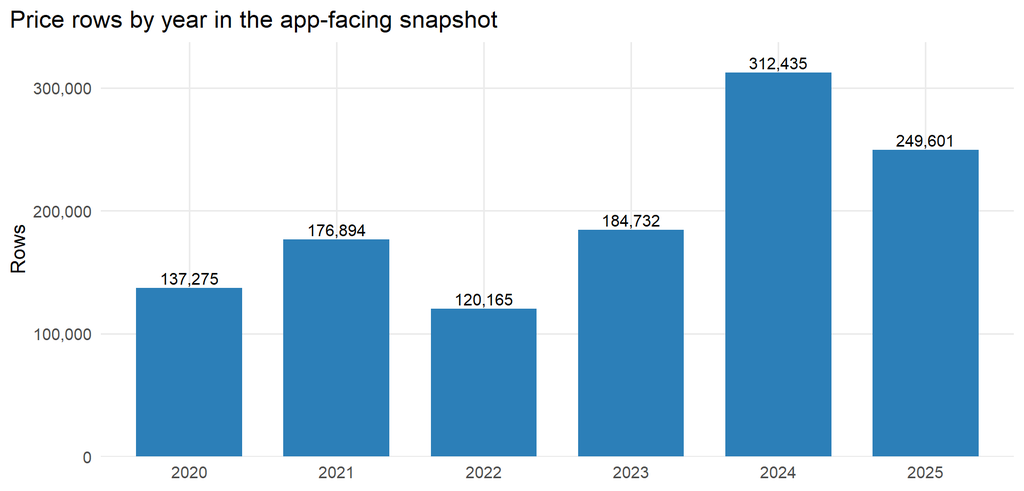

App-facing coverage by year

| Year | Rows | Chains | Sources | Median price | Non-sale rows | Sale rows |
| --- | --- | --- | --- | --- | --- | --- |
| 2020 | 137,275 | 161 | 173 | $6.99 | 107,875 | 29,400 |
| 2021 | 176,894 | 195 | 205 | $6.95 | 143,747 | 33,147 |
| 2022 | 120,165 | 258 | 273 | $6.99 | 100,070 | 20,095 |
| 2023 | 184,732 | 262 | 278 | $8.99 | 158,282 | 26,450 |
| 2024 | 312,435 | 251 | 264 | $8.99 | 264,129 | 48,306 |
| 2025 | 249,601 | 227 | 238 | $7.49 | 216,287 | 33,314 |

## 2.1 Sale status and location specificity

Most app-facing rows are marked non-sale, but the archive still contains a sizable sale layer. The location story is more mixed: a large share of rows are chain-wide, while store-specific and city-level records make up the strongest part of the map-oriented experience.

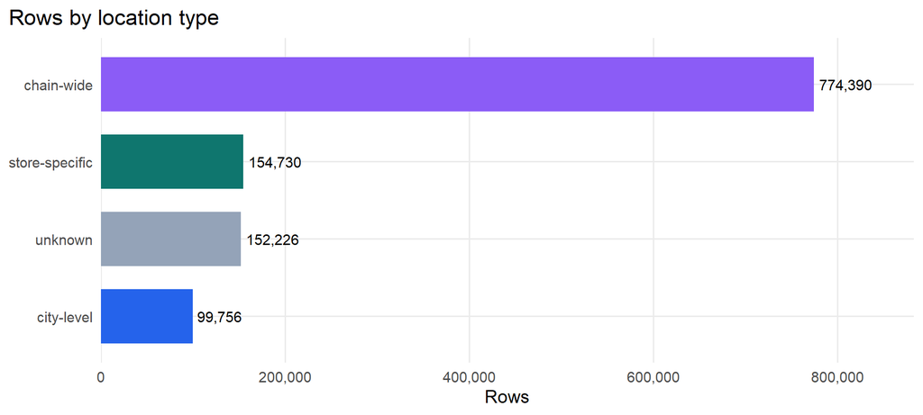

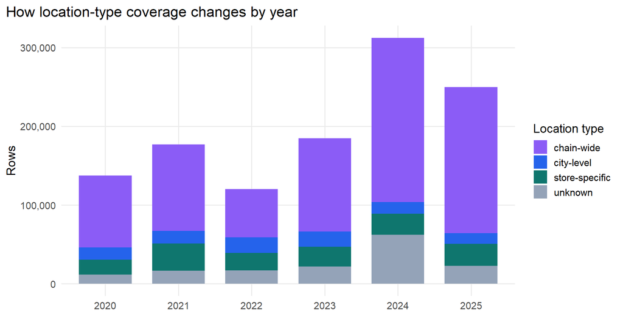

The heaviest row-producing sources in the app-facing snapshot are not all equally clean or equally mission-qualified. Some are excellent store-specific datasets; others are large but chain-wide or QA-heavy. That is why raw app coverage and confirmed-store counts should not be treated as the same thing.

Largest chains in the app-facing snapshot

| Chain | Rows | Years represented | Location types |
| --- | --- | --- | --- |
| European Deli | 271,310 | 6 | chain-wide |
| Hannaford Supermarket & Pharmacy | 86,383 | 6 | store-specific |
| H Mart | 70,638 | 2 | chain-wide |
| Olive May Health Food Store | 57,689 | 3 | chain-wide |
| Hays Food Town | 53,218 | 6 | chain-wide, city-level, unknown |
| Highlands Organic Market | 33,217 | 6 | city-level |
| Garcia Plaza Bakery | 31,163 | 2 | chain-wide |
| Amish Manhattan Farmers Market | 22,667 | 4 | unknown |
| Wild Fork Foods | 19,203 | 4 | chain-wide |
| Stew Leonard’s | 18,751 | 6 | chain-wide |
| Striplings General Store | 18,573 | 6 | chain-wide |
| Gordon Food Service Store Mp131 | 17,268 | 6 | unknown |
| ShopRite | 17,177 | 5 | city-level, store-specific, unknown |
| Joseph’s Classic Market | 15,475 | 3 | chain-wide |
| Rouses Market | 15,202 | 6 | chain-wide |

# 3 How to Use the App

The Streamlit app is best understood as a guided way to move from broad coverage to specific evidence.

## 3.1 Step 1: Start on the Pricing Map

Use the left sidebar to narrow the dataset before reading any statistics. The most important controls are:

- product categories or baskets
- sale status
- location precision
- year range

The map and the right-hand directory panel update together.

[figure not shown]

Pricing Map. Start here: set the filters in the left sidebar, then use the map and directory panel together to decide which parts of the archive you want to inspect.

## 3.2 Step 2: Scroll down to the aggregate statistics

Once the filters are set, the Pricing Map tab also acts like a summary dashboard. This is the quickest way to see how many rows, chains, and products survive the current filter choices, along with a year-over-year median price view.

[figure not shown]

## 3.3 Step 3: Use Product View to rank what is actually available

The Product View tab shifts attention away from geography and toward item-level breadth. It is useful for asking which product names have the most data points, how many years they cover, and how widely they appear across chains and locations.

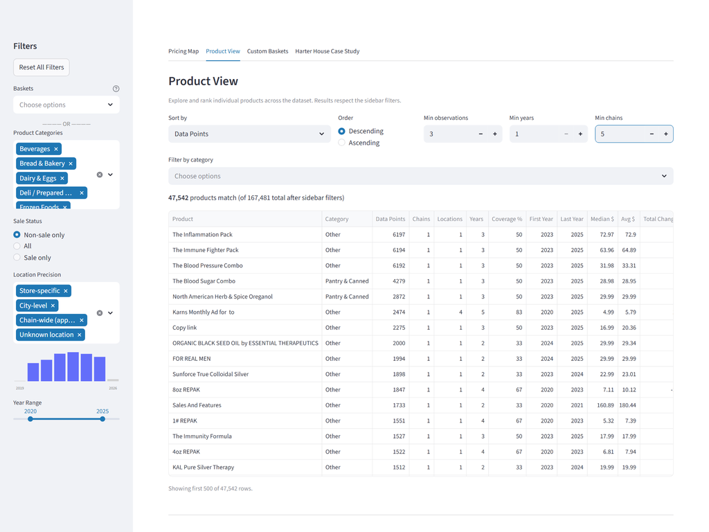

Product View. After tightening the sidebar filters, this tab is useful for ranking products by observations, chain count, years covered, and price levels.

## 3.4 Step 4: Use the Harter House tab as a guided case study

The Harter House case study is the most presentation-ready part of the app. It turns a single chain into a narrative example, showing geography, bundle structure, and time-series evidence in one place.

[figure not shown]

Harter House Case Study. This tab is the clearest single example of how the archive can be turned into an interpretable historical pricing story.

# 4 Key Caveats

Several caveats matter for any public reading of the archive:

1. **Data collection is ongoing.** This report reflects current collection status at time of writing. The app dataset may have been added or modified subsequent to report publication.
2. **Geographic precision varies.** The app contains chain-wide, city-level, unknown-location, and partially qualified material alongside the strongest store-specific records.
3. **Quality review is still active.** The current QAQC summary flags **499 files** overall, and **340 of those flagged basenames** still appear in the current dataset snapshot.
4. **Some very large sources are not the strongest inflation evidence.** Large chain-wide or noisy sources can dominate raw row counts while still being weaker than smaller, cleaner store-specific series.

# 5 Bottom Line

The archive is already large enough to be more than a proof of concept.

The main caution is not that the archive lacks data. It is that the archive contains layers of data with different strengths. **The best way to use the app is to keep those layers explicit**.